# Project 2 Technical Report

Sofia Caceres, Jonathan Haugstad, David Kirkland

2025-11-03

The MLB has 30 teams split into 6 divisions of 5 teams each. These 6 divisions are further separated into 2 leagues, the National League (NL), and the American League (AL), with 3 divisions and subsequently 15 teams in each. The current playoff format for the league is a 12 team format, 6 from each league. Each division winner is assured a top 3 seed in their league and then next 3 best teams based on record fill out the remaining playoff seeds. The teams are then arranged into a playoff bracket.

The two division winners with the best record in each league receive a bye in the first round, the Wild-Card Round. The remaining division winner, the 3 seed, plays the 6 seed, the playoff team with the worst record, and the 4 and 5 seeds play each other in best of 3 series. The winner of the the 4 vs 5 series plays the 1 seed in the next round and the winner of the 3 vs 6 series plays the 2 seed. Those match-ups in the Division Series are best of 5, and the winner of those face each other in the ALCS or NLCS Championship series in a best of 7. The AL and NL champs face off in the World Series in a best of 7 and the winner is the MLB champion in that year.

An important thing to note for this playoff format is the home field advantage teams gain by higher seeding. Teams with the higher seed in their match-up receive home field advantage which means in the series they will host more home games than their lower seeded opponent. In the Wild-Card Round, the higher seed gets to play at home all three games. In the Division Round the home teams hosts the first two games, and the last game, hosting 3 of the 5 if all games were played in the series. In the Championship Series and the World Series, games 1, 2, 6 & 7 are played at the higher seeded teams home stadium, and games 3, 4, & 5 at the lower seeds home. The higher seeded team in the World Series, since these teams were not seeded together, is the team with the better regular season record.

Playoffs in Sport are all about promoting competition and seeing who truly is the best team that year. One way that can be interrupted is by pre existing rules that grant worse teams, advantages in the playoffs, giving them a better chance to win the league even if they were worse than other playoff teams in the regular season. In the playoff seeding system the MLB has in place, there are scenarios where this is easily possible. Granting division winners guaranteed highest seeds, irregardless of record, can create a scenario where a division winner can be seeded higher than one or multiple teams with a better regular season record. With the MLB also fixing match-ups in advance, having the 4/5 seed always play the 1 seed instead of rearranging the match-ups based on seed so the 1 seed plays the lowest remaining seed in the playoffs, can also create a scenario where a 4 or 5 seed team, that was better than the 2 or 3 seed in the regular season has to not only play in the Wild-Card Round but also the 1 seed in the next round, giving them a very difficult route to winning the league even though they were a top team in the regular season.

That is the case for the New York Yankees in the most recent 2025 MLB playoffs. They lost the division title to the Toronto Blue Jays on a head-to-head tiebreaker, and so despite having the tied the Blue Jays for best record in the AL, they were the 4 seed in the playoffs and then faced Toronto in the AL Division Series (ALDS) and lost.

For our project we want to see if changing the MLB playoff format would significantly change the predicted outcome of the MLB playoffs. We aim to make the regular season results more impactful in the outcome of the playoffs, giving better teams their deserved chance to win the title that season.

To do this we would seed the playoffs by regular season record, tie-breaker being head to head record, granting guaranteed playoff spots to division winners but not a guaranteed top 3 seed. After the Wild-Card Round we’d then re-arrange the match-ups so the 1 seed faces the lowest remaining seed and the 2 seed faces the highest remaining seed.

We focused our project on the 2025 MLB season.

```r
rm(list = ls())
library(dplyr)
library(tidyr)
library(purrr)
library(stringr)
library(tibble)
library(lubridate)
library(BradleyTerry2)
library(baseballr)

set.seed(42)
```

To start, we took the 2025 MLB season from the baseballr package and look sift the data for every game in the regular season that was completed. We took the home and away teams and scores and team ID’s for each game and made a new table with this paired down data of the 2025 MLB season. We needed to manually delete four games from the dataset as they were repeated games.

```r
schedule = mlb_schedule(season = 2025) %>%
  filter(
    status_detailed_state %in% c("Final", "Completed Early"),
    game_type == "R"
  ) %>%
  transmute(
    game_date = as.Date(game_date),
    home_team_id  = as.integer(teams_home_team_id),
    away_team_id  = as.integer(teams_away_team_id),
    home_team     = teams_home_team_name,
    away_team     = teams_away_team_name,
    home_score    = as.integer(teams_home_score),
    away_score    = as.integer(teams_away_score)
  ) %>%
  filter(!is.na(home_score), !is.na(away_score)) %>%
  # Remove the specific duplicate games
  filter(!(
    (game_date == as.Date("2025-07-02") & home_team == "Boston Red Sox" & away_team == "Cincinnati Reds" & home_score == 5 & away_score == 3) |
    (game_date == as.Date("2025-06-07") & home_team == "Cincinnati Reds" & away_team == "Arizona Diamondbacks" & home_score == 4 & away_score == 3) |
    (game_date == as.Date("2025-08-02") & home_team == "Cincinnati Reds" & away_team == "Atlanta Braves" & home_score == 2 & away_score == 4) |
    (game_date == as.Date("2025-05-21") & home_team == "Minnesota Twins" & away_team == "Cleveland Guardians" & home_score == 6 & away_score == 5)
  ))

head(schedule)
```

```
## ── MLB Schedule data from MLB.com ─────────────────────────── baseballr 1.6.0 ──
```

```
## ℹ Data updated: 2025-11-07 14:11:59 CST
```

```
## # A tibble: 6 × 7
##   game_date  home_team_id away_team_id home_team away_team home_score away_score
##   <date>            <int>        <int> <chr>     <chr>          <int>      <int>
## 1 2025-03-18          112          119 Chicago … Los Ange…          1          4
## 2 2025-03-19          112          119 Chicago … Los Ange…          3          6
## 3 2025-03-27          147          158 New York… Milwauke…          4          2
## 4 2025-03-27          141          110 Toronto … Baltimor…          2         12
## 5 2025-03-27          140          111 Texas Ra… Boston R…          2          5
## 6 2025-03-27          120          143 Washingt… Philadel…          3          7
```

Next, we went through and matched each team to their corresponding league in the MLB, or giving the team an N/A value if they weren’t an MLB team, and then filtered to only include MLB teams with their matched NL or AL league.

```r
team_map <- mlb_teams(season = 2025) %>%
  transmute(
    team_id   = as.integer(team_id),
    team      = team_full_name,
    league_id = as.integer(league_id),
    league    = case_when(
      league_id == 103 ~ "AL",
      league_id == 104 ~ "NL",
      TRUE ~ NA_character_
    )
  ) %>%
  filter(!is.na(league)) %>%
  mutate(team_key = toupper(gsub(" ", "_", team)))
```

Now using these connected team ID’s, we joined the full regular season game results table we created with the home and away team’s normalized keys and a newly created column that tracks whether or not the home team in the selected game won or not.

```r
games = schedule %>%
  left_join(team_map %>% select(team_id, team_key), by = c("home_team_id"="team_id")) %>%
  rename(home_key = team_key) %>%
  left_join(team_map %>% select(team_id, team_key), by = c("away_team_id"="team_id")) %>%
  rename(away_key = team_key) %>%
  mutate(home_win = as.integer(home_score > away_score))

head(games)
```

```
## ── MLB Schedule data from MLB.com ─────────────────────────── baseballr 1.6.0 ──
```

```
## ℹ Data updated: 2025-11-07 14:11:59 CST
```

```
## # A tibble: 6 × 10
##   game_date  home_team_id away_team_id home_team away_team home_score away_score
##   <date>            <int>        <int> <chr>     <chr>          <int>      <int>
## 1 2025-03-18          112          119 Chicago … Los Ange…          1          4
## 2 2025-03-19          112          119 Chicago … Los Ange…          3          6
## 3 2025-03-27          147          158 New York… Milwauke…          4          2
## 4 2025-03-27          141          110 Toronto … Baltimor…          2         12
## 5 2025-03-27          140          111 Texas Ra… Boston R…          2          5
## 6 2025-03-27          120          143 Washingt… Philadel…          3          7
## # ℹ 3 more variables: home_key <chr>, away_key <chr>, home_win <int>
```

As stated, our goal for this project was to evaluate whether giving home field advantage to teams purely off of regular season record would change the outcome of the MLB postseason. Now we officially start the process of figuring that out. Here we get every team’s win-loss record for the regular season and then we ranked them by record in their respective leagues. We also added in measures that tracked the head-to-head tie breaker for teams against each other so we could make sure our seeding was correct. There were three massively important examples of this this past season, with the Blue Jays being seeded higher than the Yankees, the Reds being seeded higher than the Mets, and the Tigers being seeded higher than the Astros. In every case, the teams had the same record and the Blue Jays, Reds, and Tigers had better head to head records over their respective opponents and thus were seeded higher. This has, crucially, been accurately reflected in our model.

We now can start to see some differences from the real world seeds. In the AL, the Yankees move from the 4 seed in this years playoffs to the 2 seed receiving a Wild-Card Round bye, where the Mariners would be the team most upset by this switch as they lose their bye in this playoff seeding becoming the 3 seed. The Guardians still make the playoffs off of record alone, not getting in just because of their division title, but with the new seeding system they are the 5 seed, below Boston, not given the 3 seed. Detroit remains the 6 seed, unchanged.

On the flip side of our re-seeded playoff picture, the NL would remain unchanged by our re-seeding initially. The three division winners were the top three teams by regular season record, so any changes in how the NL playoffs happened will have to come after the Wild-Card Round where there is the possibility of re-arranged match-ups.

```r
standings <- games %>%
  mutate(winner = if_else(home_win==1, home_key, away_key)) %>%
  select(home_key, away_key, winner) %>%
  pivot_longer(c(home_key, away_key), values_to = "team_key") %>%
  mutate(win = as.integer(team_key == winner)) %>%
  group_by(team_key) %>%
  summarise(W = sum(win), L = n()-sum(win), GP=n(), Wpct = W/(W+L), .groups="drop") %>%
  left_join(team_map %>% select(team_key, team_id, team, league), by="team_key")

calculate_h2h <- function(team1, team2, games_df) {
  h2h_games <- games_df %>%
    filter((home_key == team1 & away_key == team2) | (home_key == team2 & away_key == team1))
  if(nrow(h2h_games) == 0) return(0.5)
  team1_wins <- h2h_games %>%
    mutate(team1_win = case_when(
      home_key == team1 & home_win == 1 ~ 1,
      away_key == team1 & home_win == 0 ~ 1,
      TRUE ~ 0
    )) %>%
    summarise(wins = sum(team1_win)) %>%
    pull(wins)
  return(team1_wins / nrow(h2h_games))
}

seed_league <- function(league_code){
  league_standings <- standings %>%
    filter(league == league_code)
  initial_order <- league_standings %>%
    arrange(desc(Wpct), desc(W), desc(GP))
  final_order <- initial_order %>%
    mutate(temp_rank = row_number()) %>%
    group_by(Wpct, W, GP) %>%
    mutate(tie_count = n()) %>%
    ungroup()
  tied_groups <- final_order %>%
    filter(tie_count > 1) %>%
    group_by(Wpct, W, GP) %>%
    group_split()
  for(group in tied_groups) {
    tied_teams <- group$team_key
    start_rank <- min(group$temp_rank)
    if(length(tied_teams) > 1) {
      h2h_matrix <- matrix(0, nrow = length(tied_teams), ncol = length(tied_teams))

      for(i in 1:length(tied_teams)) {
        for(j in 1:length(tied_teams)) {
          if(i != j) {
            h2h_matrix[i,j] <- calculate_h2h(tied_teams[i], tied_teams[j], games)
          }
        }
      }

      h2h_win_pct <- rowMeans(h2h_matrix, na.rm = TRUE)

      tied_order <- order(h2h_win_pct, decreasing = TRUE)
      sorted_teams <- tied_teams[tied_order]

      for(i in seq_along(sorted_teams)) {
        final_order$temp_rank[final_order$team_key == sorted_teams[i]] <- start_rank + i - 1
      }
    }
  }

  final_order %>%
    arrange(temp_rank) %>%
    mutate(seed = row_number()) %>%
    select(league, seed, team_key, team, W, L, Wpct)
}

seeds_AL <- seed_league("AL")
seeds_NL <- seed_league("NL")

cat("AL Standings (with H2H tiebreakers):\n")
```

```
## AL Standings (with H2H tiebreakers):
```

```r
print(seeds_AL, n = 15)
```

```
## # A tibble: 15 × 7
##    league  seed team_key            team                    W     L  Wpct
##    <chr>  <int> <chr>               <chr>               <int> <int> <dbl>
##  1 AL         1 TORONTO_BLUE_JAYS   Toronto Blue Jays      94    68 0.580
##  2 AL         2 NEW_YORK_YANKEES    New York Yankees       94    68 0.580
##  3 AL         3 SEATTLE_MARINERS    Seattle Mariners       90    72 0.556
##  4 AL         4 BOSTON_RED_SOX      Boston Red Sox         89    73 0.549
##  5 AL         5 CLEVELAND_GUARDIANS Cleveland Guardians    88    74 0.543
##  6 AL         6 DETROIT_TIGERS      Detroit Tigers         87    75 0.537
##  7 AL         7 HOUSTON_ASTROS      Houston Astros         87    75 0.537
##  8 AL         8 KANSAS_CITY_ROYALS  Kansas City Royals     82    80 0.506
##  9 AL         9 TEXAS_RANGERS       Texas Rangers          81    81 0.5
## 10 AL        10 TAMPA_BAY_RAYS      Tampa Bay Rays         77    85 0.475
## 11 AL        11 ATHLETICS           Athletics              76    86 0.469
## 12 AL        12 BALTIMORE_ORIOLES   Baltimore Orioles      75    87 0.463
## 13 AL        13 LOS_ANGELES_ANGELS  Los Angeles Angels     72    90 0.444
## 14 AL        14 MINNESOTA_TWINS     Minnesota Twins        70    92 0.432
## 15 AL        15 CHICAGO_WHITE_SOX   Chicago White Sox      60   102 0.370
```

```r
cat("\nNL Standings (with H2H tiebreakers):\n")
```

```
##
## NL Standings (with H2H tiebreakers):
```

```r
print(seeds_NL, n = 15)
```

```
## # A tibble: 15 × 7
##    league  seed team_key              team                      W     L  Wpct
##    <chr>  <int> <chr>                 <chr>                 <int> <int> <dbl>
##  1 NL         1 MILWAUKEE_BREWERS     Milwaukee Brewers        97    65 0.599
##  2 NL         2 PHILADELPHIA_PHILLIES Philadelphia Phillies    96    66 0.593
##  3 NL         3 LOS_ANGELES_DODGERS   Los Angeles Dodgers      93    69 0.574
##  4 NL         4 CHICAGO_CUBS          Chicago Cubs             92    70 0.568
##  5 NL         5 SAN_DIEGO_PADRES      San Diego Padres         90    72 0.556
##  6 NL         6 CINCINNATI_REDS       Cincinnati Reds          83    79 0.512
##  7 NL         7 NEW_YORK_METS         New York Mets            83    79 0.512
##  8 NL         8 SAN_FRANCISCO_GIANTS  San Francisco Giants     81    81 0.5
##  9 NL         9 ARIZONA_DIAMONDBACKS  Arizona Diamondbacks     80    82 0.494
## 10 NL        10 MIAMI_MARLINS         Miami Marlins            79    83 0.488
## 11 NL        11 ST._LOUIS_CARDINALS   St. Louis Cardinals      78    84 0.481
## 12 NL        12 ATLANTA_BRAVES        Atlanta Braves           76    86 0.469
## 13 NL        13 PITTSBURGH_PIRATES    Pittsburgh Pirates       71    91 0.438
## 14 NL        14 WASHINGTON_NATIONALS  Washington Nationals     66    96 0.407
## 15 NL        15 COLORADO_ROCKIES      Colorado Rockies         43   119 0.265
```

Next, we created a Bradley-Terry Model to create a latent strength estimate for each MLB team based on their 2025 season results. We created a temporary data frame that tracks the winner of each game, whether they were home or away, and then applies a home team advantage to the teams that won at home while not doing so for the teams that won on the road. Then we fit the model, modeling both team strength and home field advantage, with our reference team of the San Francisco Giants.

We chose San Francisco as the reference team as they were 81-81 in the regular season which means they won 81 games and lost 81 games, and as we saw above, finished 8th in the NL. Based on those parameters we also could have chosen the Texas Rangers as our reference as they also finished 81-81 and were 9th in the AL. Either way both teams were the very definition of average for the 2025 MLB season, so they seemed like a good fit to be our reference for our model.

Looking at the summary results from the model, we see the league seems extremely even on paper. Outside of the Rockies who lost 17 more games than the next worst MLB team, every team’s latent strength is within the range of (-.482, .412) which on it’s own doesn’t tell us much. Checking the standard deviations though, again not including the Rockies, every team’s standard deviation on their latent strength is around .22 which is a large amount to vary when their strength was only as high as .412 to begin with. This tells us that using this Bradley-Terry Model, we believe almost every MLB team to be decently close to each other in latent strength. We still see some differences in strength but when predicting these teams at a neutral site game we would expect the odds to be closer to 50/50 than something drastically in favor of one team.

Importantly though, these MLB playoff games are not neutral site games, and looking at the “at home” coefficient in our summary results we see an estimate of .178 and is statistically significant. This further emphasizes the importance of our project, as our model shows a definitive advantage playing at home, and we are adjusting the seeding to give the better teams, more home games in the playoffs. This aligns with our project goal of having the MLB playoffs redesigned to crown the best MLB team that year.

```r
tmp_df <- data.frame(
  home.win = games$home_win,
  away.win = 1 - games$home_win
)
tmp_df$home.team <- data.frame(
  team = games$home_key,
  at.home = 1
)
tmp_df$away.team <- data.frame(
  team = games$away_key,
  at.home = 0
)

all_teams <- unique(c(games$home_key, games$away_key))
tmp_df$home.team$team <- factor(tmp_df$home.team$team, levels = all_teams)
tmp_df$away.team$team <- factor(tmp_df$away.team$team, levels = all_teams)

fit <- BradleyTerry2::BTm(
  outcome = cbind(home.win, away.win),
  player1 = home.team,
  player2 = away.team,
  formula = ~ team + at.home,
  refcat = "SAN_FRANCISCO_GIANTS",
  id = "team",
  data = tmp_df
)

summary(fit)
```

```
##
## Call:
## BradleyTerry2::BTm(outcome = cbind(home.win, away.win), player1 = home.team,
##     player2 = away.team, formula = ~team + at.home, id = "team",
##     refcat = "SAN_FRANCISCO_GIANTS", data = tmp_df)
##
## Coefficients:
##                           Estimate Std. Error z value Pr(>|z|)
## teamCHICAGO_CUBS           0.28977    0.22343   1.297   0.1947
## teamNEW_YORK_YANKEES       0.36214    0.22776   1.590   0.1118
## teamTORONTO_BLUE_JAYS      0.37182    0.22782   1.632   0.1027
## teamTEXAS_RANGERS          0.03414    0.22618   0.151   0.8800
## teamWASHINGTON_NATIONALS  -0.35178    0.22449  -1.567   0.1171
## teamKANSAS_CITY_ROYALS     0.03578    0.22676   0.158   0.8746
## teamHOUSTON_ASTROS         0.15688    0.22668   0.692   0.4889
## teamCINCINNATI_REDS        0.08656    0.22253   0.389   0.6973
## teamSAN_DIEGO_PADRES       0.21395    0.21806   0.981   0.3265
## teamCHICAGO_WHITE_SOX     -0.48169    0.22987  -2.095   0.0361 *
## teamMIAMI_MARLINS         -0.03565    0.22249  -0.160   0.8727
## teamST._LOUIS_CARDINALS   -0.03114    0.22251  -0.140   0.8887
## teamLOS_ANGELES_DODGERS    0.28148    0.21856   1.288   0.1978
## teamARIZONA_DIAMONDBACKS  -0.02237    0.21737  -0.103   0.9180
## teamSEATTLE_MARINERS       0.24692    0.22689   1.088   0.2765
## teamTAMPA_BAY_RAYS        -0.03206    0.22665  -0.141   0.8875
## teamMILWAUKEE_BREWERS      0.41226    0.22393   1.841   0.0656 .
## teamBALTIMORE_ORIOLES     -0.08505    0.22697  -0.375   0.7079
## teamPHILADELPHIA_PHILLIES  0.36900    0.22368   1.650   0.0990 .
## teamATHLETICS             -0.08456    0.22443  -0.377   0.7063
## teamMINNESOTA_TWINS       -0.24098    0.22745  -1.060   0.2894
## teamDETROIT_TIGERS         0.14789    0.22672   0.652   0.5142
## teamBOSTON_RED_SOX         0.24397    0.22713   1.074   0.2828
## teamNEW_YORK_METS          0.06729    0.22255   0.302   0.7624
## teamCOLORADO_ROCKIES      -0.96334    0.23202  -4.152 3.30e-05 ***
## teamPITTSBURGH_PIRATES    -0.19801    0.22326  -0.887   0.3751
## teamATLANTA_BRAVES        -0.09904    0.22280  -0.445   0.6567
## teamLOS_ANGELES_ANGELS    -0.17188    0.22684  -0.758   0.4486
## teamCLEVELAND_GUARDIANS    0.17626    0.22682   0.777   0.4371
## at.home                    0.17840    0.04154   4.294 1.75e-05 ***
## ---
## Signif. codes:  0 '***' 0.001 '**' 0.01 '*' 0.05 '.' 0.1 ' ' 1
##
## (Dispersion parameter for binomial family taken to be 1)
##
##     Null deviance: 3368.7  on 2430  degrees of freedom
## Residual deviance: 3255.8  on 2400  degrees of freedom
## AIC: 3315.8
##
## Number of Fisher Scoring iterations: 4
```

Looking at the playoff teams, we have a smaller spread from the league best Brewers to the Reds, .412 to .087, as shown below.

These latent strength estimates from our Bradley-Terry Model are actually the log odds of a team to beat any other team. Using this we can actually exponentiate these log odds to calculate the probability that one team beats another if we subtract their exponentiated log odds from each other and account for the home field advantage estimate. We did so with the Dodgers and Blue Jays below, this years World Series teams. We calculate the log odds of the Dodgers beating the Blue Jays at home by subtracting the Blue Jays log odds from the dodgers and then adding the home field advantage in. We do the same but subtract the home field advantage estimate from the equation to get the Dodgers percentage chance of beating the Blue Jays on the road, and then leave off the home field advantage completely when calculating the win percentage chance at a neutral site.

With our model, we predict the Dodgers to beat the Blue Jays 52.2% of the time when at home, 43.32% of the time when at Toronto, and 47.74% of the time at a neutral site. It was a 7 game world series with the final game going to extra innings so it seems accurate our model would predict these teams to be close as well. The biggest factor between them would seem to be having home field advantage.

Exponentiating the home field advantage log odds estimate, we see that a team playing at home increases their odds to win by roughly 4.4%. Thus going from playing at home to on the road against an opponnent would see your predicted chance of winning drop about 8.8%. This is a significant percentage amount, and makes the impact of re-seeding teams and changing who gets more home playoff games versus away playoff games that much more important.

```r
lambda0_hat <- coef(fit)["at.home"]
lambda_hat <- BradleyTerry2::BTabilities(fit)

al_playoff_teams <- seeds_AL %>% filter(seed <= 6) %>% pull(team_key)
nl_playoff_teams <- seeds_NL %>% filter(seed <= 6) %>% pull(team_key)
playoff_teams <- c(al_playoff_teams, nl_playoff_teams)

playoff_abilities <- as.data.frame(lambda_hat) %>%
  filter(rownames(.) %in% playoff_teams) %>%
  arrange(desc(ability))

cat("=== PLAYOFF TEAMS ABILITIES (STRENGTHS) ===\n\n")
```

```
## === PLAYOFF TEAMS ABILITIES (STRENGTHS) ===
```

```r
print.data.frame(playoff_abilities, row.names = TRUE)
```

```
##                          ability      s.e.
## MILWAUKEE_BREWERS     0.41225980 0.2239334
## TORONTO_BLUE_JAYS     0.37181580 0.2278162
## PHILADELPHIA_PHILLIES 0.36900086 0.2236807
## NEW_YORK_YANKEES      0.36214242 0.2277562
## CHICAGO_CUBS          0.28977027 0.2234329
## LOS_ANGELES_DODGERS   0.28147790 0.2185584
## SEATTLE_MARINERS      0.24691867 0.2268909
## BOSTON_RED_SOX        0.24396986 0.2271334
## SAN_DIEGO_PADRES      0.21394658 0.2180632
## CLEVELAND_GUARDIANS   0.17626346 0.2268153
## DETROIT_TIGERS        0.14788973 0.2267200
## CINCINNATI_REDS       0.08655935 0.2225272
```

```r
ws_teams <- c("LOS_ANGELES_DODGERS", "TORONTO_BLUE_JAYS")

calculate_matchup_probs <- function(team1, team2) {
  lambda1 <- lambda_hat[team1, "ability"]
  lambda2 <- lambda_hat[team2, "ability"]

  log_odds_home1 <- lambda1 - lambda2 + lambda0_hat
  log_odds_home2 <- lambda1 - lambda2 - lambda0_hat
  log_odds_neutral <- lambda1 - lambda2

  prob_home1 <- exp(log_odds_home1) / (1 + exp(log_odds_home1))
  prob_home2 <- exp(log_odds_home2) / (1 + exp(log_odds_home2))
  prob_neutral <- exp(log_odds_neutral) / (1 + exp(log_odds_neutral))

  cat(sprintf("=== %s vs %s ===\n", team1, team2))
  cat(sprintf("At %s: %.2f%%\n", team1, prob_home1 * 100))
  cat(sprintf("At %s: %.2f%%\n", team2, prob_home2 * 100))
  cat(sprintf("At neutral site: %.2f%%\n", prob_neutral * 100))
  cat("\n")
}

cat("\n")
```

```r
calculate_matchup_probs("LOS_ANGELES_DODGERS", "TORONTO_BLUE_JAYS")
```

```
## === LOS_ANGELES_DODGERS vs TORONTO_BLUE_JAYS ===
## At LOS_ANGELES_DODGERS: 52.20%
## At TORONTO_BLUE_JAYS: 43.32%
## At neutral site: 47.74%
```

```r
home_adv_prob <- plogis(lambda0_hat) - 0.5
cat(sprintf("\nHome advantage: +%.1f%% win probability for home teams\n", home_adv_prob * 100))
```

```
##
## Home advantage: +4.4% win probability for home teams
```

Now that we can use the log odds of winning for each time and compute their percentage chance of doing so, we are ready to simulate the playoffs. First we need to create the functions that match each team to their BT Model log odds estimate and then exponentiate them. Next we create a function that simulates two teams with their percentage chance of winnings against each other, one at home, and the other away, and simulates a winner. This is where our random sampling happens for our upcoming Monte Carlo simulation we run. It selects a random number and lines that number up with the win probabilities to determine a winner.

Once that is assured, we create the league championship simulation function for the first two rounds that implements when to use the Best of 3, 5 and 7 series rules and adding in our re-arranged match-ups after the Wild-Card Round. This function also crucially details which teams get home field advantage in each series at each level.

```r
bt_prob <- function(home_team, away_team, i_is_home = TRUE) {
  coefs <- coef(fit)
  home_coef_name <- paste0("team", home_team)
  away_coef_name <- paste0("team", away_team)
  home_ability <- ifelse(home_coef_name %in% names(coefs), coefs[home_coef_name], 0)
  away_ability <- ifelse(away_coef_name %in% names(coefs), coefs[away_coef_name], 0)
  log_odds <- (home_ability - away_ability)
  if(i_is_home) {
    home_adv <- coefs["at.home"]
    if(!is.na(home_adv)) {
      log_odds <- log_odds + home_adv
    }
  }
  prob <- exp(log_odds) / (1 + exp(log_odds))
  return(prob)
}

sim_game <- function(home_team, away_team){
  runif(1) < bt_prob(home_team, away_team, i_is_home = TRUE)
}

sim_series <- function(high_seed, low_seed, type = c("BO3","BO5","BO7")){
  type <- match.arg(type)
  pattern <- switch(type,
                    BO3 = c("H","H","H"),
                    BO5 = c("H","H","A","A","H"),
                    BO7 = c("H","H","A","A","H","A","H"))
  hs_w <- 0; ls_w <- 0
  need <- if (type=="BO3") 2 else if (type=="BO5") 3 else 4

  for(g in seq_along(pattern)){
    home <- if (pattern[g]=="H") high_seed else low_seed
    away <- if (pattern[g]=="H") low_seed  else high_seed
    if (sim_game(home, away)) {
      if (home==high_seed) hs_w <- hs_w + 1 else ls_w <- ls_w + 1
    } else {
      if (away==high_seed) hs_w <- hs_w + 1 else ls_w <- ls_w + 1
    }
    if (hs_w==need) return(high_seed)
    if (ls_w==need) return(low_seed)
  }
  if (hs_w >= ls_w) high_seed else low_seed
}

sim_league_champ <- function(seeds_tbl){
  t1 <- seeds_tbl$team_key[seeds_tbl$seed==1]
  t2 <- seeds_tbl$team_key[seeds_tbl$seed==2]
  t3 <- seeds_tbl$team_key[seeds_tbl$seed==3]
  t4 <- seeds_tbl$team_key[seeds_tbl$seed==4]
  t5 <- seeds_tbl$team_key[seeds_tbl$seed==5]
  t6 <- seeds_tbl$team_key[seeds_tbl$seed==6]

  # Wild Card (BO3)
  wc1_winner <- sim_series(t4, t5, "BO3")
  wc2_winner <- sim_series(t3, t6, "BO3")

  # Determine which WC winner is lower seed for reseeding
  seed_of <- function(team_key) seeds_tbl$seed[match(team_key, seeds_tbl$team_key)]

  # Reseed: lowest remaining seed plays #1
  wc_winners <- c(wc1_winner, wc2_winner)
  wc_seeds <- sapply(wc_winners, seed_of)

  lower_seed_winner <- wc_winners[which.max(wc_seeds)]  # Higher seed number = lower seed
  higher_seed_winner <- wc_winners[which.min(wc_seeds)] # Lower seed number = higher seed

  # LDS (BO5) with reseeding
  d1_winner <- sim_series(t1, lower_seed_winner, "BO5")  # #1 vs lowest remaining
  d2_winner <- sim_series(t2, higher_seed_winner, "BO5") # #2 vs other WC winner

  # LCS (BO7) - higher seed gets home advantage
  lcs_seeds <- sapply(c(d1_winner, d2_winner), seed_of)
  high <- if (lcs_seeds[1] < lcs_seeds[2]) d1_winner else d2_winner
  low  <- if (identical(high, d1_winner)) d2_winner else d1_winner
  lcs_winner <- sim_series(high, low, "BO7")

  return(list(
    wild_card = list(
      matchup1 = list(team1 = t4, team2 = t5, winner = wc1_winner),
      matchup2 = list(team1 = t3, team2 = t6, winner = wc2_winner)
    ),
    lds = list(
      matchup1 = list(team1 = t1, team2 = lower_seed_winner, winner = d1_winner),
      matchup2 = list(team1 = t2, team2 = higher_seed_winner, winner = d2_winner)
    ),
    lcs = list(
      team1 = high, team2 = low, winner = lcs_winner
    ),
    champion = lcs_winner
  ))
}
```

Finally, our last function we needed to make, simulates the entire playoffs, using the functions we made above to predict an MLB Champion. This is our full Monte Carlo simulation that takes in the AL and NL seeds from the regular season, correctly identifying our playoff teams, and then runs those teams through the functions above to simulate each game, series, and round of the playoffs and get a champion. We also added code to output how many times through our simulations teams were simulated to be the World Series champ, and win their league championship title.

We simulated the 2025 MLB Playoffs with our re-seeded and re-structured bracket 2000 times and here are the results. The Brewers won the most times with 402 World Series titles, which was 20.1% of the simulations. The Blue Jays were a close second with 346 titles or 17.3% of the titles. Third and Fourth were the Yankees and Phillies winning 15.4% and 15% of the time respectively, and below them, no other team won the World Series more than 5.9% of the time. The actual World Series Champion Dodgers were that team, clearly not having good odds to win in our re-seeded model. The Dodgers only made it to the World Series in 12.6% of simulations, winning in just less than half of their appearances.

Looking just at World Series titles, AL titles and NL titles simulated, we can clearly see a sizable percentage drop off in each category between the top 4 teams in the Blue Jays, Yankees, Brewers and Phillies and the other 8 playoff teams, which is not a coincidence. These 4 teams all received the first round bye, so they had less chances of losing in the playoffs, automatically surviving the first round. They also had home advantage guaranteed to them in the second round as well, which as we showed earlier was a significant detail. Giving these teams these advantages clearly increased their title odds over the rest but they also earned these advantages in the regular season. We can break this down further though and evaluate exactly who gets both the best chances of making it in this alternative playoff bracket and who’s chances are worse.

```r
simulate_playoffs <- function(N_SIM = 2000){
  champs <- character(N_SIM)
  al_ch <- character(N_SIM)
  nl_ch <- character(N_SIM)
  al_details <- list()
  nl_details <- list()

  for(s in seq_len(N_SIM)){
    al_details[[s]] <- sim_league_champ(seeds_AL)
    nl_details[[s]] <- sim_league_champ(seeds_NL)
    al_ch[s] <- al_details[[s]]$champion
    nl_ch[s] <- nl_details[[s]]$champion
    seed_of_AL <- seeds_AL$seed[match(al_ch[s], seeds_AL$team_key)]
    seed_of_NL <- seeds_NL$seed[match(nl_ch[s], seeds_NL$team_key)]

    if (seed_of_AL < seed_of_NL) {
      champs[s] <- sim_series(al_ch[s], nl_ch[s], "BO7")
    } else if (seed_of_NL < seed_of_AL) {
      champs[s] <- sim_series(nl_ch[s], al_ch[s], "BO7")
    } else {
      arow <- standings %>% filter(team_key==al_ch[s])
      nrow <- standings %>% filter(team_key==nl_ch[s])
      al_better <- (arow$Wpct > nrow$Wpct) | ((arow$Wpct == nrow$Wpct) & (arow$W > nrow$W))
      champs[s] <- if (isTRUE(al_better)) sim_series(al_ch[s], nl_ch[s], "BO7") else sim_series(nl_ch[s], al_ch[s], "BO7")
    }
  }
  return(list(
    ws = tibble(team_key = champs) %>% count(team_key, name="WS_titles") %>%
      mutate(pct = WS_titles/sum(WS_titles)) %>%
      left_join(team_map %>% select(team_key, team), by="team_key") %>%
      arrange(desc(pct)),
    al = tibble(team_key = al_ch) %>% count(team_key, name="AL_titles") %>%
      mutate(pct = AL_titles/sum(AL_titles)) %>%
      left_join(team_map %>% select(team_key, team), by="team_key") %>%
      arrange(desc(pct)),
    nl = tibble(team_key = nl_ch) %>% count(team_key, name="NL_titles") %>%
      mutate(pct = NL_titles/sum(NL_titles)) %>%
      left_join(team_map %>% select(team_key, team), by="team_key") %>%
      arrange(desc(pct)),
    al_details = al_details,
    nl_details = nl_details
  ))
}
set.seed(42)
playoff_results <- simulate_playoffs(N_SIM = 2000)

cat("=== World Series Champions ===\n")
```

```
## === World Series Champions ===
```

```r
print(playoff_results$ws)
```

```
## # A tibble: 12 × 4
##    team_key              WS_titles    pct team
##    <chr>                     <int>  <dbl> <chr>
##  1 MILWAUKEE_BREWERS           402 0.201  Milwaukee Brewers
##  2 TORONTO_BLUE_JAYS           346 0.173  Toronto Blue Jays
##  3 NEW_YORK_YANKEES            309 0.154  New York Yankees
##  4 PHILADELPHIA_PHILLIES       300 0.15   Philadelphia Phillies
##  5 LOS_ANGELES_DODGERS         118 0.059  Los Angeles Dodgers
##  6 CHICAGO_CUBS                117 0.0585 Chicago Cubs
##  7 SEATTLE_MARINERS            114 0.057  Seattle Mariners
##  8 BOSTON_RED_SOX               95 0.0475 Boston Red Sox
##  9 SAN_DIEGO_PADRES             63 0.0315 San Diego Padres
## 10 CLEVELAND_GUARDIANS          62 0.031  Cleveland Guardians
## 11 DETROIT_TIGERS               45 0.0225 Detroit Tigers
## 12 CINCINNATI_REDS              29 0.0145 Cincinnati Reds
```

```r
cat("\n=== ALCS Winners ===\n")
```

```
##
## === ALCS Winners ===
```

```r
print(playoff_results$al)
```

```
## # A tibble: 6 × 4
##   team_key            AL_titles    pct team
##   <chr>                   <int>  <dbl> <chr>
## 1 TORONTO_BLUE_JAYS         649 0.324  Toronto Blue Jays
## 2 NEW_YORK_YANKEES          596 0.298  New York Yankees
## 3 SEATTLE_MARINERS          262 0.131  Seattle Mariners
## 4 BOSTON_RED_SOX            220 0.11   Boston Red Sox
## 5 CLEVELAND_GUARDIANS       151 0.0755 Cleveland Guardians
## 6 DETROIT_TIGERS            122 0.061  Detroit Tigers
```

```r
cat("\n=== NLCS Winners ===\n")
```

```
##
## === NLCS Winners ===
```

```r
print(playoff_results$nl)
```

```
## # A tibble: 6 × 4
##   team_key              NL_titles    pct team
##   <chr>                     <int>  <dbl> <chr>
## 1 MILWAUKEE_BREWERS           713 0.356  Milwaukee Brewers
## 2 PHILADELPHIA_PHILLIES       569 0.284  Philadelphia Phillies
## 3 LOS_ANGELES_DODGERS         252 0.126  Los Angeles Dodgers
## 4 CHICAGO_CUBS                241 0.120  Chicago Cubs
## 5 SAN_DIEGO_PADRES            143 0.0715 San Diego Padres
## 6 CINCINNATI_REDS              82 0.041  Cincinnati Reds
```

Using the code below we get the percentage chance of each team winning each specific playoff game, based on the log odds of its strength we calculated, and we then do this for every round. For example, if we follow the World Series winning Dodgers through our Predicted MLB Playoff Model, we see in their wild card game we predicted them to beat the Reds in 64.3% of the simulations. Since they are the 3 seed they would always face our 2 seed in our model, the Phillies, and we predicted them to win in this round and match-up in 28.8% of our simulations. In those 28.8% of the simulations we have the Dodgers going on and winning the NLCS in 12.6% of predictions. These wins could be against any team, we just are calculating the percentage of times the Dodgers win the NL Pennant.

For other teams, like for example the Cleveland Guardians who were the 5 seed in the AL, their probability to win their Wild-Card series against the Red Sox was 43.3%. Then dependent on which team won the 3v6 Wild-Card Series they had split odds to advance into the ALCS as they could face the Blue Jays if they were the lowest seed left with odds to win of 10.6%, or face the Yankees with 7.2% chance to win. Combined we predicted them to make it to the ALCS 17.8% of the time, as you can see in the Total Advancement Odds Section of the code results. In those 17.8% of simulations the Guardians made the NLCS round we then predicted them to win against whoever their opponent was 7.55% of the time, and from those win the World Series 3.1% of the time as shown above.

```r
calculate_round_probs <- function(details, seeds_tbl, league_name) {
  teams <- seeds_tbl$team_key

  wc1_winners <- sapply(details, function(x) x$wild_card$matchup1$winner)
  wc2_winners <- sapply(details, function(x) x$wild_card$matchup2$winner)
  lds1_winners <- sapply(details, function(x) x$lds$matchup1$winner)
  lds2_winners <- sapply(details, function(x) x$lds$matchup2$winner)
  lcs_winners <- sapply(details, function(x) x$lcs$winner)

  matchup_probs <- bind_rows(
    # Wild Card
    data.frame(team = teams) %>%
      mutate(wc1_prob = sapply(teams, function(t) mean(wc1_winners == t)),
             wc2_prob = sapply(teams, function(t) mean(wc2_winners == t))) %>%
      pivot_longer(cols = c(wc1_prob, wc2_prob), names_to = "round", values_to = "probability") %>%
      mutate(round = ifelse(round == "wc1_prob", "wild_card1", "wild_card2")),

    # LDS
    data.frame(team = teams) %>%
      mutate(lds1_prob = sapply(teams, function(t) mean(lds1_winners == t)),
             lds2_prob = sapply(teams, function(t) mean(lds2_winners == t))) %>%
      pivot_longer(cols = c(lds1_prob, lds2_prob), names_to = "round", values_to = "probability") %>%
      mutate(round = ifelse(round == "lds1_prob", "lds1", "lds2")),

    # LCS
    data.frame(team = teams, probability = sapply(teams, function(t) mean(lcs_winners == t))) %>%
      mutate(round = "lcs")
  ) %>% filter(probability > 0)

  total_advancement <- bind_rows(
    # Wild Card to LDS
    data.frame(
      team = teams,
      probability = sapply(teams, function(t) {
        mean(sapply(details, function(sim) {
          t %in% c(sim$wild_card$matchup1$winner, sim$wild_card$matchup2$winner)
        }))
      }),
      round = "advance_to_lds"
    ),
    # LDS to LCS
    data.frame(
      team = teams,
      probability = sapply(teams, function(t) {
        mean(sapply(details, function(sim) {
          t %in% c(sim$lds$matchup1$winner, sim$lds$matchup2$winner)
        }))
      }),
      round = "advance_to_lcs"
    ),
    # LCS to WS
    data.frame(
      team = teams,
      probability = sapply(teams, function(t) mean(lcs_winners == t)),
      round = "advance_to_ws"
    )
  ) %>% filter(probability > 0)
  list(
    matchup_odds = matchup_probs %>% arrange(round, desc(probability)),
    advancement_odds = total_advancement %>% arrange(round, desc(probability))
  )
}

al_results <- calculate_round_probs(playoff_results$al_details, seeds_AL, "AL")
nl_results <- calculate_round_probs(playoff_results$nl_details, seeds_NL, "NL")

cat("=== AL PLAYOFF ODDS ===\n")
```

```
## === AL PLAYOFF ODDS ===
```

```r
cat("\n--- MATCHUP-SPECIFIC ODDS ---\n")
```

```
##
## --- MATCHUP-SPECIFIC ODDS ---
```

```r
al_results$matchup_odds %>%
  group_by(round) %>%
  do({
    cat("\n", .$round[1], ":\n")
    print(.[, c("team", "probability")], row.names = FALSE)
    data.frame()
  })
```

```
##
##  lcs :
## # A tibble: 6 × 2
##   team                probability
##   <chr>                     <dbl>
## 1 TORONTO_BLUE_JAYS        0.324
## 2 NEW_YORK_YANKEES         0.298
## 3 SEATTLE_MARINERS         0.131
## 4 BOSTON_RED_SOX           0.11
## 5 CLEVELAND_GUARDIANS      0.0755
## 6 DETROIT_TIGERS           0.061
##
##  lds1 :
## # A tibble: 4 × 2
##   team                probability
##   <chr>                     <dbl>
## 1 TORONTO_BLUE_JAYS         0.592
## 2 DETROIT_TIGERS            0.152
## 3 BOSTON_RED_SOX            0.15
## 4 CLEVELAND_GUARDIANS       0.106
##
##  lds2 :
## # A tibble: 4 × 2
##   team                probability
##   <chr>                     <dbl>
## 1 NEW_YORK_YANKEES         0.567
## 2 SEATTLE_MARINERS         0.270
## 3 BOSTON_RED_SOX           0.0905
## 4 CLEVELAND_GUARDIANS      0.072
##
##  wild_card1 :
## # A tibble: 2 × 2
##   team                probability
##   <chr>                     <dbl>
## 1 BOSTON_RED_SOX            0.567
## 2 CLEVELAND_GUARDIANS       0.433
##
##  wild_card2 :
## # A tibble: 2 × 2
##   team             probability
##   <chr>                  <dbl>
## 1 SEATTLE_MARINERS       0.610
## 2 DETROIT_TIGERS         0.390
```

```
## # A tibble: 0 × 1
## # Groups:   round [0]
## # ℹ 1 variable: round <chr>
```

```r
cat("\n--- TOTAL ADVANCEMENT ODDS ---\n")
```

```
##
## --- TOTAL ADVANCEMENT ODDS ---
```

```r
al_results$advancement_odds %>%
  group_by(round) %>%
  do({
    round_name <- case_when(
      .$round[1] == "advance_to_lds" ~ "Advance to LDS",
      .$round[1] == "advance_to_lcs" ~ "Advance to LCS",
      .$round[1] == "advance_to_ws" ~ "Advance to World Series",
      TRUE ~ .$round[1]
    )
    cat("\n", round_name, ":\n")
    print(.[, c("team", "probability")], row.names = FALSE)
    data.frame()
  })
```

```
##
##  Advance to LCS :
## # A tibble: 6 × 2
##   team                probability
##   <chr>                     <dbl>
## 1 TORONTO_BLUE_JAYS         0.592
## 2 NEW_YORK_YANKEES          0.567
## 3 SEATTLE_MARINERS          0.270
## 4 BOSTON_RED_SOX            0.240
## 5 CLEVELAND_GUARDIANS       0.178
## 6 DETROIT_TIGERS            0.152
##
##  Advance to LDS :
## # A tibble: 4 × 2
##   team                probability
##   <chr>                     <dbl>
## 1 SEATTLE_MARINERS          0.610
## 2 BOSTON_RED_SOX            0.567
## 3 CLEVELAND_GUARDIANS       0.433
## 4 DETROIT_TIGERS            0.390
##
##  Advance to World Series :
## # A tibble: 6 × 2
##   team                probability
##   <chr>                     <dbl>
## 1 TORONTO_BLUE_JAYS        0.324
## 2 NEW_YORK_YANKEES         0.298
## 3 SEATTLE_MARINERS         0.131
## 4 BOSTON_RED_SOX           0.11
## 5 CLEVELAND_GUARDIANS      0.0755
## 6 DETROIT_TIGERS           0.061
```

```
## # A tibble: 0 × 1
## # Groups:   round [0]
## # ℹ 1 variable: round <chr>
```

```r
cat("\n=== NL PLAYOFF ODDS ===\n")
```

```
##
## === NL PLAYOFF ODDS ===
```

```r
cat("\n--- MATCHUP-SPECIFIC ODDS ---\n")
```

```
##
## --- MATCHUP-SPECIFIC ODDS ---
```

```r
nl_results$matchup_odds %>%
  group_by(round) %>%
  do({
    cat("\n", .$round[1], ":\n")
    print(.[, c("team", "probability")], row.names = FALSE)
    data.frame()
  })
```

```
##
##  lcs :
## # A tibble: 6 × 2
##   team                  probability
##   <chr>                       <dbl>
## 1 MILWAUKEE_BREWERS          0.356
## 2 PHILADELPHIA_PHILLIES      0.284
## 3 LOS_ANGELES_DODGERS        0.126
## 4 CHICAGO_CUBS               0.120
## 5 SAN_DIEGO_PADRES           0.0715
## 6 CINCINNATI_REDS            0.041
##
##  lds1 :
## # A tibble: 4 × 2
##   team              probability
##   <chr>                   <dbl>
## 1 MILWAUKEE_BREWERS       0.616
## 2 CHICAGO_CUBS            0.164
## 3 CINCINNATI_REDS         0.114
## 4 SAN_DIEGO_PADRES        0.106
##
##  lds2 :
## # A tibble: 4 × 2
##   team                  probability
##   <chr>                       <dbl>
## 1 PHILADELPHIA_PHILLIES      0.557
## 2 LOS_ANGELES_DODGERS        0.288
## 3 CHICAGO_CUBS               0.095
## 4 SAN_DIEGO_PADRES           0.0605
##
##  wild_card1 :
## # A tibble: 2 × 2
##   team             probability
##   <chr>                  <dbl>
## 1 CHICAGO_CUBS           0.574
## 2 SAN_DIEGO_PADRES       0.426
##
##  wild_card2 :
## # A tibble: 2 × 2
##   team                probability
##   <chr>                     <dbl>
## 1 LOS_ANGELES_DODGERS       0.643
## 2 CINCINNATI_REDS           0.357
```

```
## # A tibble: 0 × 1
## # Groups:   round [0]
## # ℹ 1 variable: round <chr>
```

```r
cat("\n--- TOTAL ADVANCEMENT ODDS ---\n")
```

```
##
## --- TOTAL ADVANCEMENT ODDS ---
```

```r
nl_results$advancement_odds %>%
  group_by(round) %>%
  do({
    round_name <- case_when(
      .$round[1] == "advance_to_lds" ~ "Advance to LDS",
      .$round[1] == "advance_to_lcs" ~ "Advance to LCS",
      .$round[1] == "advance_to_ws" ~ "Advance to World Series",
      TRUE ~ .$round[1]
    )
    cat("\n", round_name, ":\n")
    print(.[, c("team", "probability")], row.names = FALSE)
    data.frame()
  })
```

```
##
##  Advance to LCS :
## # A tibble: 6 × 2
##   team                  probability
##   <chr>                       <dbl>
## 1 MILWAUKEE_BREWERS           0.616
## 2 PHILADELPHIA_PHILLIES       0.557
## 3 LOS_ANGELES_DODGERS         0.288
## 4 CHICAGO_CUBS                0.258
## 5 SAN_DIEGO_PADRES            0.166
## 6 CINCINNATI_REDS             0.114
##
##  Advance to LDS :
## # A tibble: 4 × 2
##   team                probability
##   <chr>                     <dbl>
## 1 LOS_ANGELES_DODGERS       0.643
## 2 CHICAGO_CUBS              0.574
## 3 SAN_DIEGO_PADRES          0.426
## 4 CINCINNATI_REDS           0.357
##
##  Advance to World Series :
## # A tibble: 6 × 2
##   team                  probability
##   <chr>                       <dbl>
## 1 MILWAUKEE_BREWERS          0.356
## 2 PHILADELPHIA_PHILLIES      0.284
## 3 LOS_ANGELES_DODGERS        0.126
## 4 CHICAGO_CUBS               0.120
## 5 SAN_DIEGO_PADRES           0.0715
## 6 CINCINNATI_REDS            0.041
```

```
## # A tibble: 0 × 1
## # Groups:   round [0]
## # ℹ 1 variable: round <chr>
```

Below are graphs that show each team’s advancement probabilities by each round, split by league.

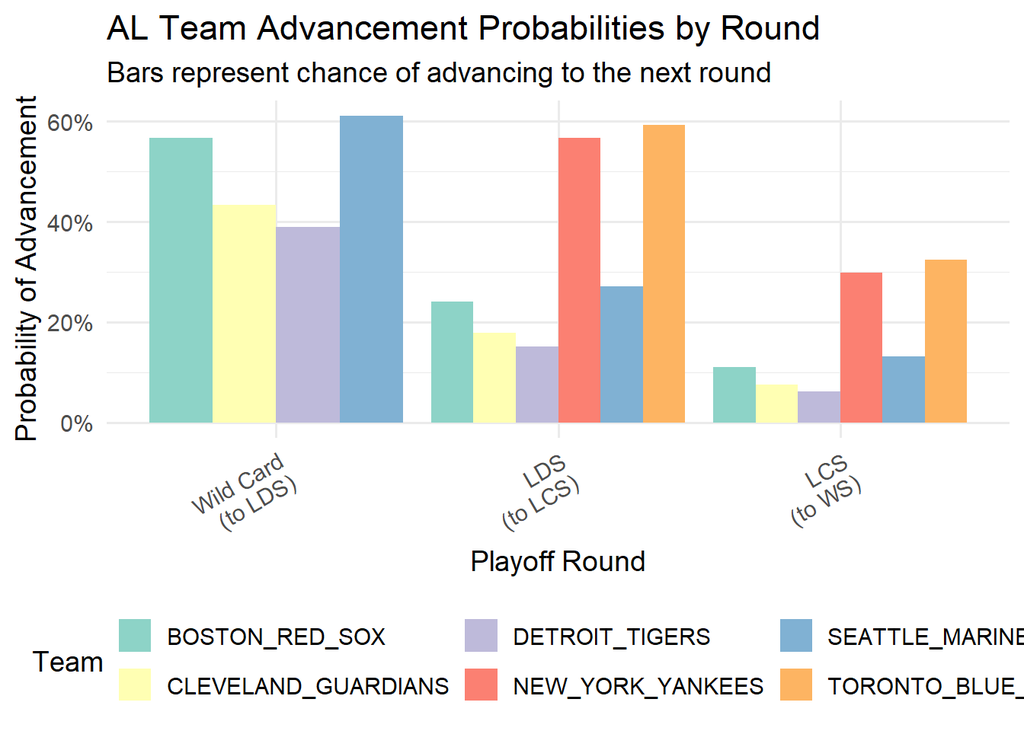

```r
library(ggplot2)
library(scales)
adv_plot_data <- bind_rows(
  al_results$advancement_odds %>% mutate(league = "AL"),
  nl_results$advancement_odds %>% mutate(league = "NL")
) %>%
  mutate(
    from_round = factor(round,
                       levels = c("advance_to_lds", "advance_to_lcs", "advance_to_ws"),
                       labels = c("Wild Card\n(to LDS)", "LDS\n(to LCS)", "LCS\n(to WS)"))
  )

# AL Graph
ggplot(adv_plot_data %>% filter(league == "AL"),
       aes(x = from_round, y = probability, fill = team)) +
  geom_col(position = "dodge") +
  scale_y_continuous(labels = scales::percent_format(accuracy = 1)) +
  scale_fill_brewer(palette = "Set3") +
  labs(
    title = "AL Team Advancement Probabilities by Round",
    subtitle = "Bars represent chance of advancing to the next round",
    x = "Playoff Round",
    y = "Probability of Advancement",
    fill = "Team"
  ) +
  theme_minimal(base_size = 14) +
  theme(
    axis.text.x = element_text(angle = 30, hjust = 1),
    legend.position = "bottom"
  )
```

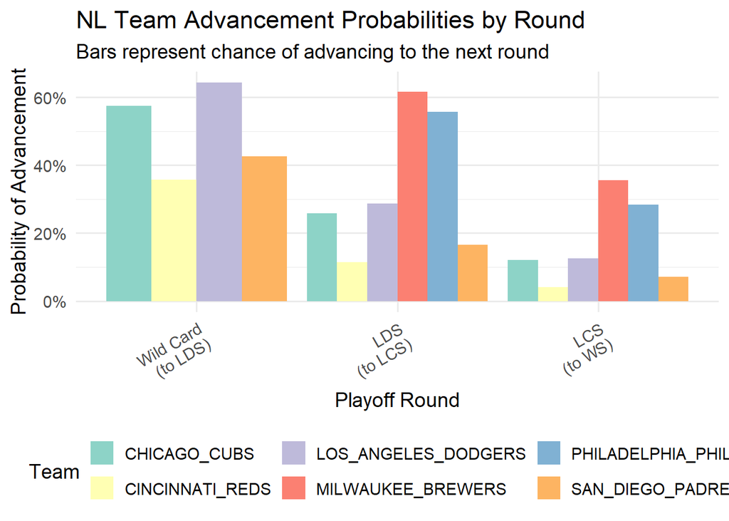

```r
# NL graph
ggplot(adv_plot_data %>% filter(league == "NL"),
       aes(x = from_round, y = probability, fill = team)) +
  geom_col(position = "dodge") +
  scale_y_continuous(labels = scales::percent_format(accuracy = 1)) +
  scale_fill_brewer(palette = "Set3") +
  labs(
    title = "NL Team Advancement Probabilities by Round",
    subtitle = "Bars represent chance of advancing to the next round",
    x = "Playoff Round",
    y = "Probability of Advancement",
    fill = "Team"
  ) +
  theme_minimal(base_size = 14) +
  theme(
    axis.text.x = element_text(angle = 30, hjust = 1),
    legend.position = "bottom"
  )
```

This is a graph that displays each Playoff teams Probability of Winning the 2025 World Series with our Monte Carlo simulation and reseedings.

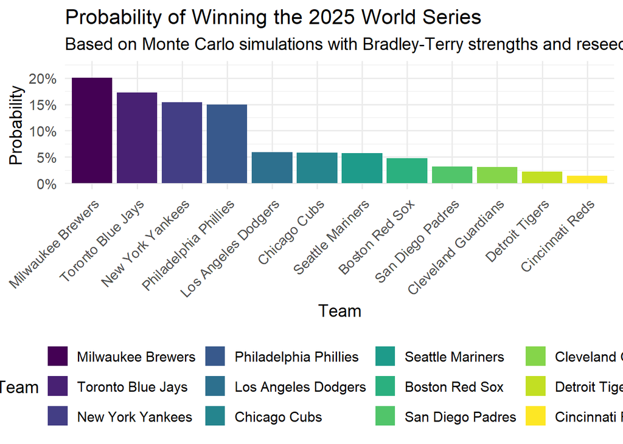

```r
ws_data <- playoff_results$ws %>%
  arrange(desc(pct)) %>%
  mutate(team = factor(team, levels = team))

ggplot(ws_data, aes(x = team, y = pct, fill = team)) +
  geom_col() +
  scale_y_continuous(labels = percent_format(accuracy = 1), limits = c(0, max(ws_data$pct)*1.1)) +
  scale_fill_viridis_d() +
  labs(
    title = "Probability of Winning the 2025 World Series",
    subtitle = "Based on Monte Carlo simulations with Bradley-Terry strengths and reseeding",
    x = "Team",
    y = "Probability",
    fill = "Team"
  ) +
  theme_minimal(base_size = 14) +
  theme(
    axis.text.x = element_text(angle = 45, hjust = 1),
    legend.position = "bottom"
  )
```

To wrap up, it is clear and obvious based on our 2000 simulations of our model that by re-seeding the Playoffs by regular season record and restructuring the match-ups after the first round, the teams that earned a top two seed in their league were most likely to win the World Series. It wasn’t guaranteed, all 12 teams won the title at least 29 times and 7 of the 12 won it over 100 times, but it was much more likely these top 2 seeds from either league won the title, winning 1357 of the 2000 simulations, 67.85%. It was even between the top teams, a slight advantage to the 1 seeds as they won more often than the 2 seeds but that was more based on latent strength than playoff structure. Overall this model gave the best teams from the regular season the best chance to win the title, but no so heavily to remove the opportunity for a lower seed to win it all. If the MLB was looking to reformat their Playoff structure, based on our Bradley-Terry Model and Monte Carlo simulation, we believe this playoff format would fit the purpose of giving the best teams through 162 regular season games an earned advantage to win the title.